# Bank Churn Prediction - Connie Xavier

### Model 6

```python
backend.clear_session()
np.random.seed(1)
random.seed(1)
tf.random.set_seed(1)
```

```python
##Applying SMOTE on training data
smote = SMOTE(sampling_strategy="not majority")
X_sm, y_sm = smote.fit_resample(X_train, y_train)
```

```python
def build_model_2(h):
    model = keras.Sequential()
    for i in range(h.Int("num_layers", 2, 5)):
        model.add(
            layers.Dense(
                units=h.Int("units_" + str(i), min_value=8, max_value=128, step=32),
                activation="relu",
            )
        )
        model.add(layers.Dropout(0.1))
    model.add(layers.Dense(1, activation="sigmoid"))
    model.compile(
        optimizer=keras.optimizers.Adam(h.Choice("learning_rate", [1e-2, 1e-3, 1e-4])),
        loss="binary_crossentropy",
        metrics=["accuracy"],
    )
    return model
```

```python
tuner_2 = RandomSearch(
    build_model_2,
    objective="val_accuracy",
    max_trials=5,
    executions_per_trial=3,
    project_name="Job_Switch",
    overwrite=True,
)
```

```python
tuner_2.search(X_sm, y_sm, epochs=5, validation_data=(X_val, y_val))
```

```
Trial 5 Complete [00h 00m 28s]
val_accuracy: 0.7095000147819519

Best val_accuracy So Far: 0.815833330154419
Total elapsed time: 00h 02m 11s
INFO:tensorflow:Oracle triggered exit
```

```
INFO:tensorflow:Oracle triggered exit
```

```python
tuner_2.results_summary()
```

```
Results summary
Results in .\Job_Switch
Showing 10 best trials
Objective(name="val_accuracy", direction="max")

Trial 1 summary
Hyperparameters:
num_layers: 5
units_0: 72
units_1: 8
learning_rate: 0.01
units_2: 8
units_3: 8
units_4: 8
Score: 0.815833330154419

Trial 2 summary
Hyperparameters:
num_layers: 4
units_0: 72
units_1: 72
learning_rate: 0.01
units_2: 104
units_3: 8
units_4: 72
Score: 0.8153333266576132

Trial 0 summary
Hyperparameters:
num_layers: 2
units_0: 72
units_1: 104
learning_rate: 0.001
Score: 0.8043333292007446

Trial 3 summary
Hyperparameters:
num_layers: 2
units_0: 8
units_1: 72
learning_rate: 0.001
units_2: 72
units_3: 8
units_4: 72
Score: 0.7891666690508524

Trial 4 summary
Hyperparameters:
num_layers: 4
units_0: 8
units_1: 8
learning_rate: 0.0001
units_2: 40
units_3: 40
units_4: 8
Score: 0.7095000147819519
```

```python
backend.clear_session()
np.random.seed(1)
random.seed(1)
tf.random.set_seed(1)
```

```python
# create model with best stats
model6 = Sequential()
model6.add(
    Dense(
        72,
        activation="relu",
        kernel_initializer="he_uniform",
        input_dim=X_train.shape[1],
    )
)
model6.add(Dropout(0.1))
model6.add(Dense(8, activation="relu", kernel_initializer="he_uniform"))
model6.add(Dropout(0.1))
model6.add(Dense(8, activation="relu", kernel_initializer="he_uniform"))
model6.add(Dropout(0.1))
model6.add(Dense(8, activation="relu", kernel_initializer="he_uniform"))
model6.add(Dropout(0.1))
model6.add(Dense(8, activation="relu", kernel_initializer="he_uniform"))
model6.add(Dropout(0.1))
model6.add(Dense(1, activation="sigmoid"))
# Compiling the ANN with Adam optimizer and binary cross entropy loss function
optimizer = tf.keras.optimizers.Adam(0.01)
model6.compile(loss="binary_crossentropy", optimizer=optimizer, metrics=["accuracy"])
```

```python
model6.summary()
```

```
Model: "sequential"
_________________________________________________________________
 Layer (type)                Output Shape              Param #
=================================================================
 dense (Dense)               (None, 72)                864

 dropout (Dropout)           (None, 72)                0

 dense_1 (Dense)             (None, 8)                 584

 dropout_1 (Dropout)         (None, 8)                 0

 dense_2 (Dense)             (None, 8)                 72

 dropout_2 (Dropout)         (None, 8)                 0

 dense_3 (Dense)             (None, 8)                 72

 dropout_3 (Dropout)         (None, 8)                 0

 dense_4 (Dense)             (None, 8)                 72

 dropout_4 (Dropout)         (None, 8)                 0

 dense_5 (Dense)             (None, 1)                 9

=================================================================
Total params: 1,673
Trainable params: 1,673
Non-trainable params: 0
_________________________________________________________________
```

```python
# Fitting the model on train and validation with 100 epochs
history6 = model6.fit(
    X_sm,
    y_sm,
    batch_size=32,
    validation_data=(X_val, y_val),
    epochs=100,
    callbacks=es_cb,
)
```

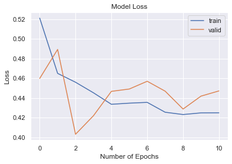

```python
# Capturing learning history per epoch
hist = pd.DataFrame(history6.history)
hist["epoch"] = history6.epoch

# Plotting accuracy at different epochs
plt.plot(hist["loss"])
plt.plot(hist["val_loss"])
plt.legend(("train", "valid"), loc=0)
plt.xlabel("Number of Epochs")
plt.ylabel("Loss")
plt.title("Model Loss")

# Printing results
results = model6.evaluate(X_val, y_val)
```

- There is a lot more noise in the data, and the validation loss is starting to increase.

```
Best Threshold=0.454992, G-Mean=0.821
```

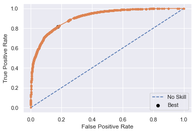

```python
# find threshold using ROC-AUC curve.
# predict probabilities
yhat1 = model6.predict(X_sm)
# keep probabilities for the positive outcome only
yhat1 = yhat1[:, 0]
# calculate roc curves
fpr, tpr, thresholds1 = roc_curve(y_sm, yhat1)
# calculate the g-mean for each threshold
# g-mean is a metric for imbalanced classification that, if optimized, will seek a balance between the sensitivity and the specificity.
gmeans1 = np.sqrt(tpr * (1 - fpr))
# locate the index of the largest g-mean
ix = np.argmax(gmeans1)
print("Best Threshold=%f, G-Mean=%.3f" % (thresholds1[ix], gmeans1[ix]))
# plot the roc curve for the model
pyplot.plot([0, 1], [0, 1], linestyle="--", label="No Skill")
pyplot.plot(fpr, tpr, marker=".")
pyplot.scatter(fpr[ix], tpr[ix], marker="o", color="black", label="Best")
# axis labels
pyplot.xlabel("False Positive Rate")
pyplot.ylabel("True Positive Rate")
pyplot.legend()
# show the plot
pyplot.show()
```

```
              precision    recall  f1-score   support

           0       0.92      0.81      0.86      1592
           1       0.49      0.72      0.58       408

    accuracy                           0.79      2000
   macro avg       0.70      0.76      0.72      2000
weighted avg       0.83      0.79      0.80      2000
```

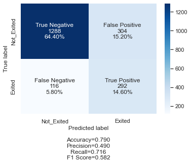

```python
# Predicting the results using best as a threshold
y_pred_e6 = model6.predict(X_val)
y_pred_e6 = y_pred_e6 > thresholds1[ix]
# Calculating the confusion matrix
cm6 = confusion_matrix(y_val, y_pred_e6)
cm6_r = stats(cm6)
labels = ["True Negative", "False Positive", "False Negative", "True Positive"]
categories = ["Not_Exited", "Exited"]
make_confusion_matrix(cm6, group_names=labels, categories=categories, cmap="Blues")

# Accuracy as per the classification report
cr6 = metrics.classification_report(y_val, y_pred_e6)
print(cr6)
```

- Generally, this model is giving good recall and accuracy based on all models so far. However, there is a lot of noise in the data.

# Part 5: Choose best model and test

```python
# compare all models
models_comp_df = pd.concat(
    [cm_r.T, cm1_r.T, cm2_r.T, cm3_r.T, cm4_r.T, cm5_r.T, cm6_r.T,], axis=1,
)
models_comp_df.columns = [
    "Model 1 (0.5 Threshold)",
    "Model 1 (ROC-AUC Threshold)",
    "Model 2",
    "Model 3",
    "Model 4",
    "Model 5",
    "Model 6",
]

print("Validation performance comparison:")
models_comp_df
```

```
Validation performance comparison:
```

|  | Model 1 (0.5 Threshold) | Model 1 (ROC-AUC Threshold) | Model 2 | Model 3 | Model 4 | Model 5 | Model 6 |
| --- | --- | --- | --- | --- | --- | --- | --- |
| Accuracy | 0.843500 | 0.801500 | 0.767000 | 0.802000 | 0.775000 | 0.793000 | 0.790000 |
| Recall | 0.526961 | 0.715686 | 0.644608 | 0.730392 | 0.767157 | 0.757353 | 0.715686 |
| Precision | 0.641791 | 0.509599 | 0.450342 | 0.510274 | 0.468563 | 0.495192 | 0.489933 |
| F1 | 0.578735 | 0.595311 | 0.530242 | 0.600806 | 0.581784 | 0.598837 | 0.581673 |

- Model 1 using the default 0.5 threshold had the highest accuracy but the lowest recall.
- The highest recall is from Model 4. However, there was a little overfitting to the training data and more noise.
- We will go with Model 3, as it had the third highest recall, good accuracy, least overfitting, and smoother curves.

```python
# find best threshold from model using ROC-AUC curve for chosen model
# predict probabilities
yhat1 = model3.predict(X_train)
# keep probabilities for the positive outcome only
yhat1 = yhat1[:, 0]
# calculate roc curves
fpr, tpr, thresholds1 = roc_curve(y_train, yhat1)
# calculate the g-mean for each threshold
# g-mean is a metric for imbalanced classification that, if optimized, will seek a balance between the sensitivity and the specificity.
gmeans1 = np.sqrt(tpr * (1 - fpr))
# locate the index of the largest g-mean
ix = np.argmax(gmeans1)
```

```
              precision    recall  f1-score   support

           0       0.92      0.80      0.86      1593
           1       0.48      0.72      0.58       407

    accuracy                           0.79      2000
   macro avg       0.70      0.76      0.72      2000
weighted avg       0.83      0.79      0.80      2000
```

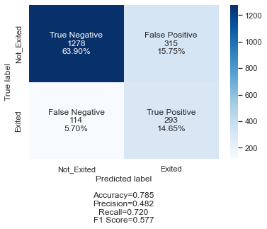

```python
# Predicting the results using best as a threshold
y_pred_test = model3.predict(X_test)
y_pred_test = y_pred_test > thresholds1[ix]
# Calculating the confusion matrix
cmtest = confusion_matrix(y_test, y_pred_test)
labels = ["True Negative", "False Positive", "False Negative", "True Positive"]
categories = ["Not_Exited", "Exited"]
make_confusion_matrix(cmtest, group_names=labels, categories=categories, cmap="Blues")

# Accuracy as per the classification report
crtest = metrics.classification_report(y_test, y_pred_test)
print(crtest)
```

# Part 6: Conclusions and Recommendations

**Data Background:**

- There are 10000 rows and 14 columns in the data.
- There are 0 duplicated rows in the data.
- Used category datatype for categorical features.

**Data Preprocessing:**

- Dropped Surname, RowNumber, and CustomerId since they are unique to each customer.
- All data appears to be valid, so no outliers were treated.
- Standardized numerical features were used in the model.
- Dummy variables were created for the categorical features.

**Observations from EDA:**

- 20.4% churned bank services.
- Most customers are male, from France, have a credit card, and are active members.
- The target variable was most correlated with Age.
- Customers who exited tend to have lower credit scores, are older, have a higher median balance, are from Germany, female, are less active with the bank, and hold only one product.

**Model Building and Performance:**

- Data was split into train, validation, and test sets.
- Recall was the chosen evaluation metric.
- Neural network models were trained with training data and tested on validation data. Final model was tested with test data.
- Model 1a: 2 hidden layers, RMSprop, 0.5 threshold
  - Model was overfitting
- Model 1b: Same as Model 1a but used threshold from ROC-AUC curve
- Model 2: 3 hidden layers, Adam, ROC-AUC threshold, BatchNormalization
  - Model was overfitting
- Model 3: 3 hidden layers, Adam, ROC-AUC threshold, Dropout, EarlyStopping
- Model 4: 3 hidden layers, Adam, ROC-AUC threshold, Dropout, EarlyStopping, Gridsearch CV to tune dropout, learning rate, and batch size.
- Model 5: 2 hidden layers, Adam, ROC-AUC threshold, Dropout, EarlyStopping, Keras Tuner and Random Search
  - Model was overfitting.
- Model 6: 5 hidden layers, Adam, ROC-AUC threshold, Dropout, EarlyStopping, SMOTE and Keras Tuner
  - A lot of noise in the model
- The final model showed 72% recall on the test data.

## Recommendations

- A neural network model was successfully built that can be used by the bank to predict which customers will likely exit the bank. It is recommended to look at more ways to tune the hyperparameters to achieve better performance.
- The more active a member is, the more likely they will not exit. The bank should focus on keeping up contact with customers and teach them about new services.
- If customers hold 2 products, they are less likely to exit the bank. The bank should focus on customers only holding one product, and see what they can market to them.
- Customers from Germany were more likely to exit, so the bank should look into ways they can improve service to these customers and what they are doing differently with other countries.
- It is recommended that the business gather more data on other features like type of product held, number of interactions, and quality of interactions to see how these may influence exits.
- The business can also focus on increasing services to countries that had a low number of customers (Germany and Spain).